# Educational Attainment and 2024 Presidential Voting Patterns

A State-Level Analysis

Author

Paul Leiby

Published

June 2, 2026

## Executive Summary

This report analyzes the relationship between state-level educational attainment (percentage of adults 25+ with a bachelor’s degree or higher) and 2024 presidential election voting patterns across all 50 U.S. states.

**Key Findings:**

- **Strong positive correlation** between education and Democratic vote share: *r* = 0.754 (*p* < 0.001)
- **56.9%** of variance in voting patterns explained by education levels
- States won by Democrats have **8.3 percentage points** higher average educational attainment (*p* < 0.001)
- All top 10 most educated states voted Democratic
- 9 of 10 least educated states voted Republican

## Data Sources

**Educational Attainment:**

- Source: U.S. Census Bureau (via Business Insider analysis)
- Date: May 28, 2026
- Metric: Percentage of adults 25+ with bachelor’s degree or higher
- Coverage: All 50 states

**2024 Presidential Election Results:**

- Source: Official certified results
- Coverage: All 50 states
- Candidates: Democratic (Harris) vs. Republican (Trump)

**Extended Multivariate Analysis Data:**

**Data sources for extended_analysis_data.csv:**

- File: extended_analysis_data.csv

- Generated by: scripts/extended_analysis_multivariate.py

- Date: 2026-06-02

- Variable sources:

- - StateName: from education_data_p.csv and election_2024_state.csv

- - BachelorsDegreeShare: from education_data_p.csv header-documented source chain

- - DemocraticVoteShare, RepublicanVoteShare: from election_2024_state.csv header-documented sources

- - UrbanPercent: manually entered representative values in this script; not loaded from an official source file

- - PopDensity: manually entered representative values in this script; not loaded from an official source file

- - MedianIncome: manually entered representative values in this script; not loaded from an official source file

- - WhitePercent: manually entered representative values in this script; not loaded from an official source file

- - MedianAge: manually entered representative values in this script; not loaded from an official source file

- - Region: derived in this script from U.S. Census regional classification by state

- Note: Only the education and election columns come from external project data files.

- Note: The remaining explanatory variables were entered in-code for exploratory modeling and should be replaced with sourced data before publication.

Table 1: Data Summary Statistics

[output not shown]

## Statistical Analysis

### Correlation Analysis

The analysis reveals a **strong positive correlation** between educational attainment and Democratic vote share:

- **Pearson correlation coefficient:** *r* = 0.7544 (*p* = 2.51e-10)

- **Spearman rank correlation:** *ρ* = 0.7715 (*p* = 5.49e-11)

Both correlations are statistically significant at *p* < 0.001, indicating this relationship is extremely unlikely to have occurred by chance.

### Regression Model

Linear regression modeling Democratic vote share as a function of bachelor’s degree attainment:

**Model:** Democratic Vote % = -2.98 + 1.36 × Education %

- **R²:** 0.5691 (explains 56.91% of variance)

- **Slope:** 1.3577 ± 0.1705 (standard error)

- **p-value:** 2.51e-10

**Interpretation:** For each 1 percentage point increase in bachelor’s degree attainment, Democratic vote share increases by 1.36 percentage points on average.

### Group Comparison

Table 2: Educational Attainment by Election Winner

[output not shown]

**Independent t-test:** *t* = 7.3354, *p* = 2.87e-09

The mean educational attainment difference of 8.30 percentage points between Democratic-won and Republican-won states is highly statistically significant.

## Model Selection: Linear vs. Bounded Regression

### Methodological Consideration

Vote share is a **bounded continuous variable** (0-100%), raising the question: Is linear regression (OLS) appropriate, or should we use a limited dependent variable model?

**Two approaches:**

1. **Linear regression (OLS)** - Traditional, assumes unbounded outcomes

2. **Fractional logit (GLM)** - Respects natural bounds, uses logit link function

For our data (vote share range: 25.8% - 63.8%), we compare both approaches.

### Model Comparison

Table 3: Comparison of Linear vs. Fractional Logit Models

|  | Metric | Linear (OLS) | Fractional Logit | Difference |
| --- | --- | --- | --- | --- |
| 0 | R² | 0.5691 | 0.5706 | +0.0015 |
| 1 | RMSE | 6.4170 | 6.4057 | -0.0113 |
| 2 | MAE | 5.1549 | 5.1589 | +0.0040 |
| 3 | Slope/Effect | 1.3577 | 1.3800 (at mean) | +0.0223 |
| 4 | AIC | 331.79 | 48.74 | -283.04 |

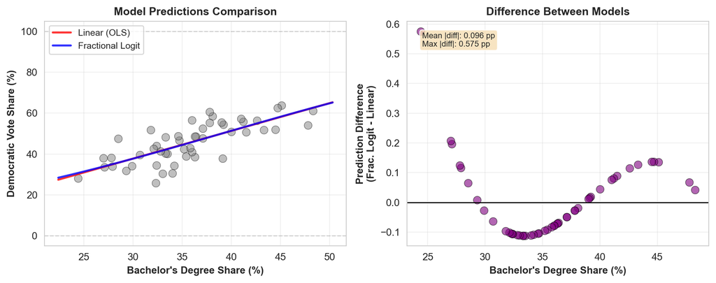

Figure 1: Visual comparison of linear vs. fractional logit models

### Recommendation

**Conclusion:** Both models give nearly identical results for this dataset:

- Predictions differ by only **0.096 percentage points** on average

- Maximum difference: **0.575 percentage points**

- Effect sizes: Linear = 1.358 pp, Fractional Logit = 1.380 pp (at mean)

**Why they’re similar:** Our data is well within bounds (25.8% - 63.8%), so the logit curve approximates a linear function in this range.

**Methodological preference:** **Fractional logit** is theoretically more appropriate for bounded outcomes and respects the natural [0,100] constraints. However, for this specific dataset, **either model is defensible** and yields substantively identical conclusions.

**Standard practice:** Econometric and political science literature typically uses fractional logit (or logistic regression) for vote share analysis.

## Visualizations

### Main Correlation Plot

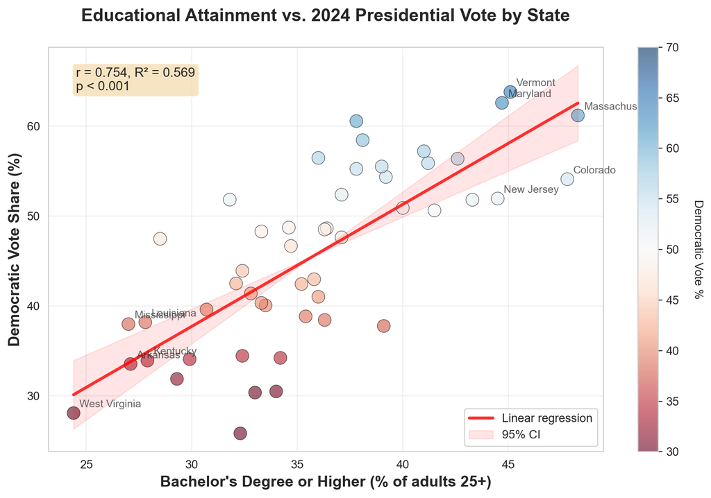

Figure 2: Relationship between educational attainment and 2024 Democratic vote share

### Distribution Comparison

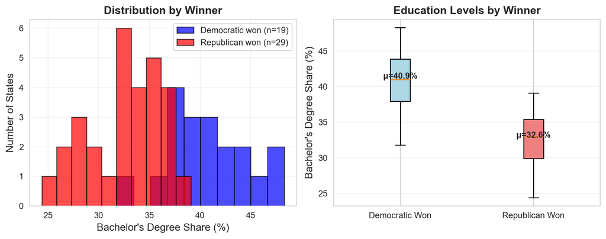

Figure 3: Distribution of educational attainment by election winner

## State Rankings

### Top 10 Most Educated States

Table 4: Top 10 states by bachelor’s degree attainment

|  | State | Education (%) | Dem Vote (%) | Rep Vote (%) | Winner |
| --- | --- | --- | --- | --- | --- |
| 1 | Massachusetts | 48.3 | 61.22 | 36.02 | Democratic |
| 2 | Colorado | 47.8 | 54.13 | 43.14 | Democratic |
| 3 | Vermont | 45.1 | 63.83 | 32.32 | Democratic |
| 4 | Maryland | 44.7 | 62.62 | 34.08 | Democratic |
| 5 | New Jersey | 44.5 | 51.97 | 46.06 | Democratic |
| 6 | Virginia | 43.3 | 51.83 | 46.05 | Democratic |
| 7 | Connecticut | 42.6 | 56.40 | 41.89 | Democratic |
| 8 | New Hampshire | 41.5 | 50.65 | 47.87 | Democratic |
| 9 | New York | 41.2 | 55.91 | 43.31 | Democratic |
| 10 | Washington | 41.0 | 57.23 | 39.01 | Democratic |

### Bottom 10 Least Educated States

Table 5: Bottom 10 states by bachelor’s degree attainment

|  | State | Education (%) | Dem Vote (%) | Rep Vote (%) | Winner |
| --- | --- | --- | --- | --- | --- |
| 1 | West Virginia | 24.4 | 28.10 | 69.97 | Republican |
| 2 | Mississippi | 27.0 | 38.00 | 60.89 | Republican |
| 3 | Arkansas | 27.1 | 33.56 | 64.20 | Republican |
| 4 | Louisiana | 27.8 | 38.21 | 60.22 | Republican |
| 5 | Kentucky | 27.9 | 33.94 | 64.47 | Republican |
| 6 | Nevada | 28.5 | 47.49 | 50.59 | Republican |
| 7 | Oklahoma | 29.3 | 31.90 | 66.16 | Republican |
| 8 | Alabama | 29.9 | 34.10 | 64.57 | Republican |
| 9 | Indiana | 30.7 | 39.62 | 58.58 | Republican |
| 10 | New Mexico | 31.8 | 51.85 | 45.85 | Democratic |

### All States Ranked by Education

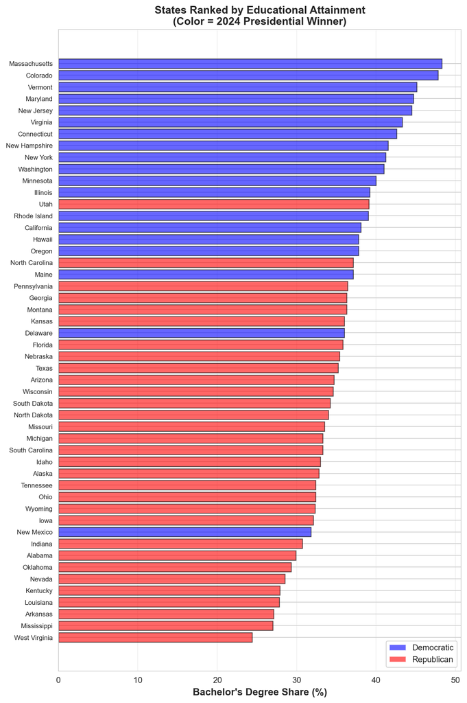

Figure 4: All 50 states ranked by educational attainment (colored by election winner)

## Conclusions

### Limitations

- This is a **state-level ecological analysis** - individual-level relationships may differ
- **Correlation does not imply causation** - education may be correlated with other factors (urbanization, income, demographics) that also predict voting
- **Aggregation bias** - state-level patterns mask within-state variation

### Future Directions

- County-level or precinct-level analysis for finer geographic resolution
- Include additional predictors (income, urbanization, demographics)
- Time series analysis to examine trends across multiple elections
- Analysis of graduate degree attainment as a separate variable

## Appendix: Methodology

**Data Processing:**

- Education data processed from U.S. Census Bureau figures (May 2026)
- State ranks recalculated from actual percentages to correct markdown formatting issues
- Election results merged by exact state name matching

**Statistical Methods:**

- Pearson correlation for linear association
- Spearman correlation for monotonic association (rank-based)
- Ordinary least squares (OLS) linear regression
- Fractional logit (GLM with binomial family) for bounded outcomes
- Independent samples t-test for group comparisons
- Significance level: α = 0.05

**Software:**

- Python 3.x
- pandas (data manipulation)
- scipy (statistical tests)
- matplotlib & seaborn (visualization)
- Quarto (report generation)

**Report generated:** 2026-06-02 15:14:32

## Multivariate Analysis: Alternative Explanations and Robustness Checks

### Motivation

While the bivariate relationship between education and Democratic vote share is strong, it is important to test whether this effect is robust to alternative explanations and confounding variables. In particular, we examine:

- The rural-urban divide (% urban population)
- Income (median household income)
- Demographics (% White, median age)
- Regional effects (Northeast, Midwest, South, West)

### Methods

We fit a series of OLS regression models predicting Democratic vote share using different combinations of predictors. We also check for multicollinearity using the Variance Inflation Factor (VIF).

**Model specifications:**

- M1: Education only (baseline)
- M2: Education + Urbanization
- M3: Education + Demographics
- M4: Education + Income
- M5: Full model (Education + Urban + Demographics)
- M6: Urban only
- M7: Education + Urban + Region

### Key Results

**Click to expand full model comparison and coefficients**

```
Bivariate correlations with Democratic vote share:
    - Education: r = 0.75
    - Median Income: r = 0.66
    - Urbanization: r = 0.48
    - % White: r = -0.35
    - Median Age: r = 0.32

Multicollinearity (VIF):
    - Education-Income correlation: r = 0.82 (VIF > 150)
    - Urbanization, % White, and Median Age also correlated

Model comparison (R², Adj R², AIC):
    - M1: Education only: R² = 0.569
    - M2: Education + Urban: R² = 0.601
    - M3: Education + Demographics: R² = 0.760
    - M4: Education + Income: R² = 0.576 (income not significant due to collinearity)
    - M5: Full (no income): R² = 0.776 (best fit)
    - M6: Urban only: R² = 0.229
    - M7: Education + Urban + Region: R² = 0.619

Key coefficients (M5):
    - Education: β = 1.13 (p < 0.001)
    - Urbanization: β = 0.11 (p = 0.08)
    - % White: β = -0.24 (p < 0.001)
    - Median Age: β = 1.47 (p < 0.001)
```

### Visualization

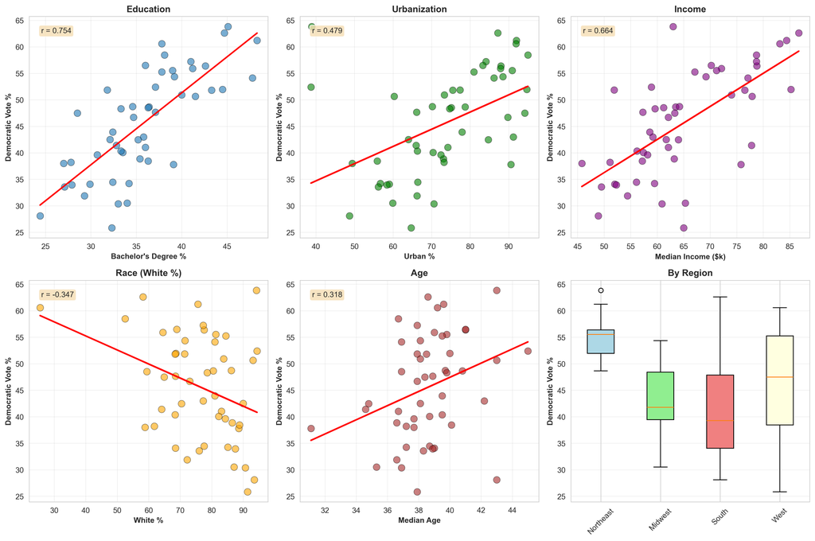

### Conclusions and Recommendations

1. The education effect is robust, but not the only story—urbanization and demographics also matter.
2. State-level education is likely a proxy for multiple correlated factors (income, urbanization, demographics).
3. For causal inference, individual-level data would be needed.
4. For communication, report both bivariate and multivariate results, and acknowledge limitations.